# How much offensive *consistency* should baseball teams want?

Statistics

Baseball

Author

Cody VanZandt

Published

November 5, 2026

Over a season, baseball teams want to score as many runs as possible. I have that fact on very good authority. I’m *less* sure, however, as to whether their offensive consistency matters. Between two teams that score the same average number of runs per game, who wins more in expectation: the team that puts up similar numbers every night? Or the team that vacillates wildly between shutouts and blowouts?

Intuitively, I thought a good team should crave consistency and a mediocre one should aim for variance. After all, a strong team’s typical game is usually good for a win, whereas a mediocre team needs things to go atypically well. It’s a reasonable theory, at least I thought. But among MLB teams, it just doesn’t seem to hold. Virtually every MLB team, at every level of offensive production, should want more consistency.

MLB teams aren’t actually that far apart in run production or prevention, runs are strongly right-skewed, and team-specific variances are quite high relative to means. Those three facts, taken together, mean that an underdog’s best chance lies in playing close to their average and hoping the other team has an off night. Now, there is *still* a situation where variance becomes desirable. If a team is so hopeless that their typical game almost never wins, then consistency won’t do them any good. They actually need variance. But those are depths of ineptitude that only one MLB team has plumbed in the last fifty years: the historically horrible 2025 Rockies, who sit right at the point where variance stops hurting. For everyone else, consistency helps.

If you’re interested in the details and the modeling assumptions, read on! A preview of coming attractions: the Pólya-Aeppli distribution, the Pythagoras-Lagrange Mediocrity Line, and the win-value of consistency.

## Distributional Assumptions for Scoring

### Poisson

To begin, I needed to find a good distribution for modeling scoring. The simplest model of counts is the Poisson, which imagines a game as a series of small, independent chances to score one run. It assumes that a given team-season has a fixed propensity for scoring, and those chances add up to an average of $\mu_i$ runs per game. The number of runs in game $g$ is then

$$Y_{ig} \sim \text{Poisson}(\mu_i), \qquad \operatorname{E}(Y_{ig}) = \operatorname{Var}(Y_{ig}) = \mu_i .$$

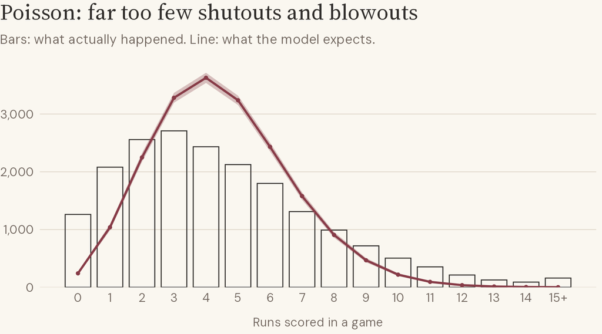

It’s a pleasingly simple model, but the fit isn’t great. Real run scoring has a variance-to-mean ratio of ~2.3 – more than twice what a Poisson distribution allows. The Poisson expects about 240 shutouts in these four seasons; there were 1,262. It expects about two games of 15 or more runs, and there were 160. To compensate, it piles games into the middle. The result is an MLB season that cannot exist, at least not until MLB execs move the pitcher’s mound behind second base and cap games at a svelte 90 minutes.

### Bunching Runs with the Negative Binomial

The Negative Binomial is a standard fix for counts that are too spread out for a Poisson. It adds one parameter, $\phi$, that controls how much additional variance one sees beyond what one would expect from a Poisson:

$$Y_{ig} \sim \text{NegBin}(\mu_i,\ \phi), \qquad \operatorname{Var}(Y_{ig}) = \mu_i + \frac{\mu_i^2}{\phi}.$$

The Negative Binomial also has a derivation that makes for a neat baseball story. Runs don’t arrive one at a time. Most innings produce nothing, and the ones that do can produce several. So split a game into two questions: how many of its innings are scoring innings, and how many runs is each scoring inning worth? If the number of scoring innings follows a Poisson and the runs within each scoring inning follow a Logarithmic distribution, then the runs in a game follow a Negative Binomial:

$$\begin{aligned}
N_{ig} &\sim \text{Poisson}\!\left(\phi \log\!\left(1 + \tfrac{\mu_i}{\phi}\right)\right), \qquad C_{igj} \sim \text{Logarithmic}\!\left(\tfrac{\mu_i}{\mu_i + \phi}\right), \\
Y_{ig} &= \textstyle\sum_{j=1}^{N_{ig}} C_{igj} \sim \text{NegBin}(\mu_i,\ \phi).
\end{aligned}$$

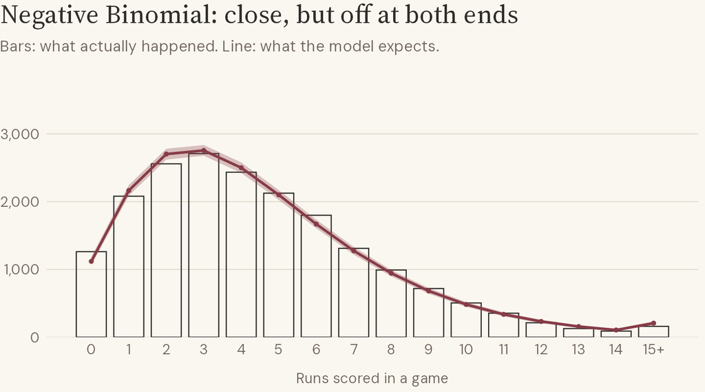

That’s much better, and for a lot of purposes it would be good enough. But four seasons is a lot of games, and the Negative Binomial is getting things wrong at the extremes. It expects about 1,120 shutouts (89% interval 1,061 to 1,185) against 1,262 real ones – about 11% too few. It also expects about 207 games of 15+ runs (181 to 235) against 160, about 30% too many. It misses in opposite directions at the two ends and no setting of $\phi$ can fix both. More variance would add shutouts and blowouts together; less variance would decrease both.

### Introducing: Pólya-Aeppli

The Pólya-Aeppli distribution, also known as the Geometric Poisson, isn’t one I’d heard about before I went looking for a fix to the Negative Binomial’s problems. It keeps the Poisson number of scoring innings and swaps the Logarithmic distribution for a Geometric one:

$$\begin{aligned}
N_{ig} &\sim \text{Poisson}(\lambda_i), \qquad C_{igj} \sim \text{Geometric}(1-\rho), \quad C_{igj} \in \{1, 2, \dots\}, \\
Y_{ig} &= \textstyle\sum_{j=1}^{N_{ig}} C_{igj} \sim \text{Pólya-Aeppli}(\lambda_i,\ \rho).
\end{aligned}$$

Its mean and variance are:

$$\operatorname{E}(Y_{ig}) = \mu_i = \frac{\lambda_i}{1-\rho}, \qquad \operatorname{Var}(Y_{ig}) = \mu_i\,\frac{1+\rho}{1-\rho}.$$

The Geometric says that once an inning is a scoring inning, every run has the same chance $\rho$ of being followed by another. I’ll call $\rho$ a team’s clumpiness. As $\rho$ grows, the same average arrives in fewer, bigger innings, which means more shutouts and more variance. Compared to the Logarithmic distribution, the Pólya-Aeppli gives us:

- **Fewer blowouts.** Because its chance of continuing never rises, the Geometric has a short tail. An inning worth eight or more runs is about 2.7 times less likely than under the Logarithmic, which removes most of the Negative Binomial’s excess.
- **More shutouts.** The Geometric’s typical scoring inning is a little bigger, so it reaches the same average with fewer of them. Fewer total scoring innings leaves room for more shutouts, which closes most of the Negative Binomial’s shortfall.

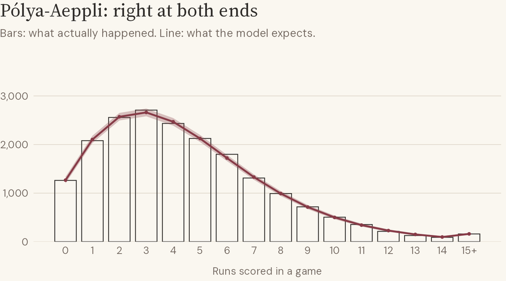

The Pólya-Aeppli expects about 1,267 shutouts (89% interval 1,199 to 1,337) against 1,262, and about 161 games of 15+ runs (89% interval 139 to 183) against 160. Across all sixteen run counts, 14 actual counts fall inside its 89% intervals, against 10 for the Negative Binomial.

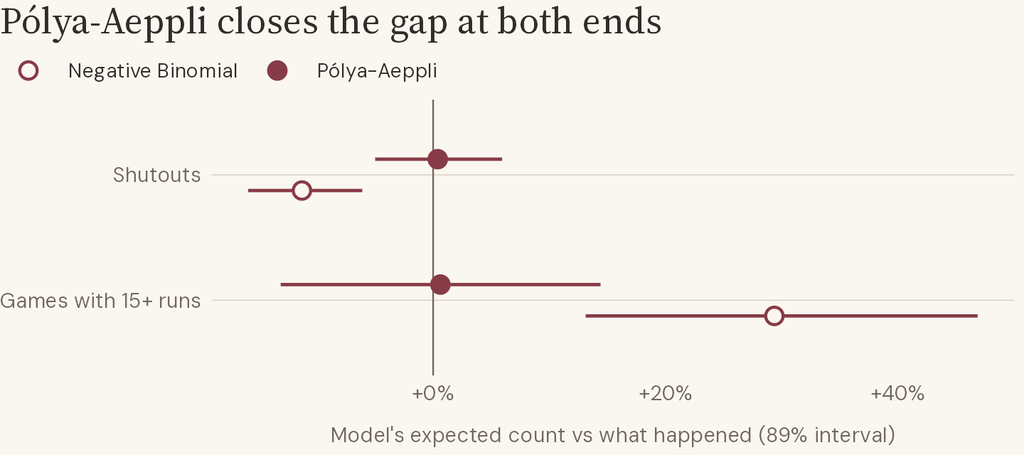

I’m sure it isn’t the only good distribution – other distributions with more granular inning-by-inning data generating stories could surely work. But all told, I’m happy to use the Pólya-Aeppli to model runs.

## Do teams differ in consistency?

Now the real question. Under the Pólya-Aeppli model, a team’s game-to-game variance depends on two things: its average and its clumpiness. The average obviously differs between teams. Does the clumpiness?

To find out, I fit a multilevel model that gave every team-season its own average and its own clumpiness, partially pooling each parameter within a season:

$$\begin{aligned}
Y_{ig} &\sim \text{Pólya-Aeppli}(\mu_i,\ \rho_i), \\
\log \mu_i &\sim \text{Normal}(\alpha^{\mu}_{s[i]},\ \tau_\mu), \qquad \operatorname{logit} \rho_i \sim \text{Normal}(\alpha^{\rho}_{s[i]},\ \tau_\rho).
\end{aligned}$$

The number that matters is $\tau_\rho$, how much clumpiness varies between team-seasons within a season. If it’s near zero, teams likely have the same underlying clumpiness and differ in run variance only because they differ in how much they score. If it’s larger, then teams could plausibly have different underlying clumpinesses.

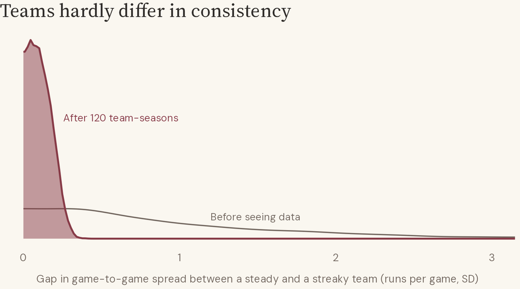

The data say they barely differ. $\tau_\rho$ comes out at about 0.05 (89% interval 0.007 to 0.105), piled up against zero. As an example, consider two teams scoring the MLB average of ~4.5 runs. One sits at the 10th percentile clumpiness, and the other at the 90th percentile. Their game-to-game standard deviations are about 3.11 and 3.22 runs. That’s… not much.

Another helpful test is to assume teams don’t differ and check whether the data are consistent with that. To that effect, I fit the same model with $\tau_\rho$ fixed at zero, so each team in a season is exactly as clumpy as every other. I then simulated thousands of replicate seasons and measured how spread out the teams’ variance-to-mean ratios came out. If teams really differed in consistency, the actual MLB spread would sit in the far tail of what identically clumpy teams would produce.

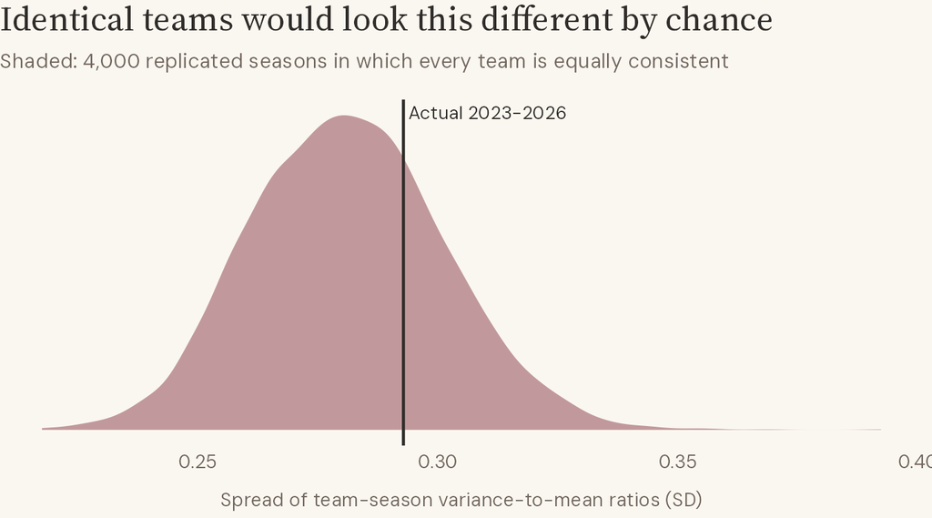

It doesn’t. The actual spread is 0.293. Identical teams produce 0.280 (89% interval 0.250 to 0.315), and 28% of the replicated seasons are actually *more* spread out than reality. I feel happy saying that the differences you’d see in a table of teams’ raw run variances are comfortably produced by the typical noise of a 162 game season, not by any true underlying differences in consistency.

## How much consistency *should* teams want?

So teams don’t differ much. That’s a bit of a shame, particularly since I was eagerly anticipating an xCLUMP stat making its way to FanGraphs. But, to answer the question from the top of this article: would it matter if teams *did* differ in consistency? And if so, should they be aiming for more or less of it? Here the Pólya-Aeppli model earns its keep: it gives the exact probability that one team outscores another, which I can then roll up into expected wins over a 162 game season.

The following graph shows what happens when a team changes its scoring variance while keeping the same average. The horizontal axis is how good the team is: its runs scored minus its runs allowed, per game. The vertical axis is how variable its scoring is, as a multiple of what’s typical for its average. The bands show how many wins that change gains or costs over a 162-game season. Each dot is a real team-season from 1975 to 2026, skipping 2020. A dot’s height is mostly noise, as we just saw, so read the dots for where teams sit from left to right. Throughout, runs scored and runs allowed are treated as independent, and ties count as half a win.

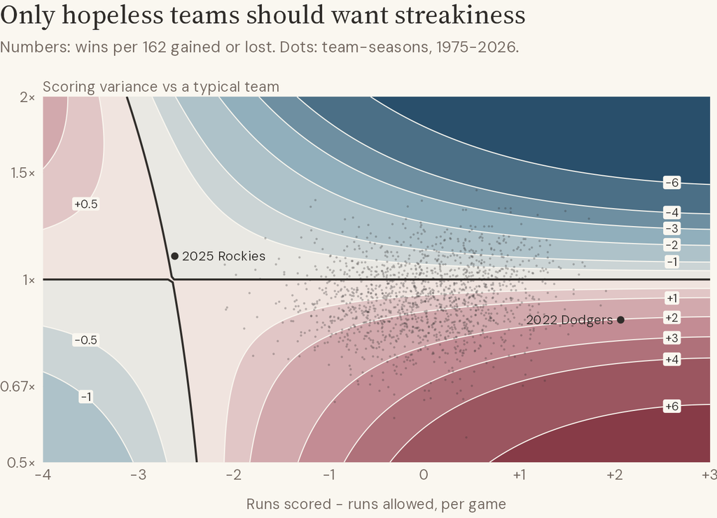

My original intuition – good teams want less variance, bad teams want more – shows up on either side of the curved black line, which I’d love to persuade folks to call the Pythagoras-Lagrange Mediocrity Line. Pythagoras, because like Pythagorean expectation, it’s built from a team’s runs scored and runs allowed. Lagrange, after the Lagrange points in astronomy, the spots near two orbiting bodies where the forces on a small object balance, letting it hold its position relative to them. On this line, the pull toward consistency and the pull toward variance cancel out: the team wins exactly as many games as it would with typical variance.

The line crosses typical variance at about -2.6 runs a game. So variance only starts to help once you’re outscored by roughly 420 runs over a season, and even then it doesn’t help much: a team outscored by four runs a game would gain about one win from raising its variance by half. In the last 51 seasons, exactly one team has reached the line. The historically horrible 2025 Rockies were outscored by 424 runs, and cutting their variance by a third or raising it by half would each have cost them about 0.2 wins. The next-worst teams, at about -2.1 runs a game, aren’t close.

Everyone else wants consistency, and the better the team, the more it wants. Cutting your variance by a third is worth about 3.0 wins to an average team and 5.1 to a team as good as the 2022 Dodgers. Raising it by half costs 4.0 and 6.5 wins respectively.

So, how much offensive consistency should a baseball team want? All that it can get. In practice, that isn’t much of a lever, because teams hardly differ in their consistency. But that they *don’t* differ doesn’t mean they *can’t*. There may very well be some mechanism by which a team can decrease its variance without simultaneously decreasing its average. Game totals alone can’t reveal such a mechanism, though, so the next step is to look at inning-by-inning and plate-appearance data, where differences in how teams build their runs should show up if they exist.

Until then, I’ll keep holding a candle for xCLUMP.

*2023-2026 game results from the MLB Stats API; 1975-2025 team-seasons from Retrosheet.*